# Twitter Stream with Tweepy

Using tweepy, we track tweets during the LA Dodgers and Colorado Rockies game on Wednesday. I thought this would be an interested game to track since Zach Greinke was starting for the Dodgers and Joc Pederson has been on a powerful home run hitting streak.

Authorization is set up using keys and access tokens provided by twitter. Tweepy's built in OAuthHandler sets up a connection with Twitter's API, and we create a StreamListener that catches all tweets filtered to our liking. For the sake of space, I put only the files that trackers all occurrences of the word 'dodgers' - the same code work for the Rockies tracker as well.

Using pymongo, we make a connection to the local MongoDB, and insert tweets documents as they come in. I started the stream about 30 minutes before the game and took a snapshot of the data in the 9th inning. The results are analyzed below.

```python
import tweepy
import sys
import pymongo

#keys are hidden from this code
ckey = ''
csec = ''
atok = ''
asec = ''

auth = tweepy.OAuthHandler(ckey, csec)
auth.set_access_token(atok, asec)
api = tweepy.API(auth)

class CustomStreamListener(tweepy.StreamListener):
    def __init__(self, api):
        self.api = api
        super(tweepy.StreamListener, self).__init__()

        self.db = pymongo.MongoClient().Dodgers

    def on_status(self, status):

        # uncomment to print tweets as they come in
        # print status.text , "\n"

        data ={}
        data['text'] = status.text
        data['created_at'] = status.created_at
        data['geo'] = status.geo
        data['source'] = status.source

        self.db.Tweets.insert(data)

    def on_error(self, status_code):
        print >> sys.stderr, 'Encountered error with status code:', status_code
        return True # Don't kill the stream

    def on_timeout(self):
        print >> sys.stderr, 'Timeout...'
        return True # Don't kill the stream

sapi = tweepy.streaming.Stream(auth, CustomStreamListener(api))
sapi.filter(track=['dodgers'])
```

# Analysis

I exported a copy of our Mongo collection using the following snippet:

```python
mongoexport -d Dodgers -c Tweets --type=csv --fields _id,text,created_at,geo,source -o Dodgers.csv
```

Using pandas, we correctly set the time, and created a new DataFrame that aggregates the tweets on a per minute basis. This allows us to identify pivotal points in the game.

```python
import pandas as pd
from pandas.tseries.resample import TimeGrouper
from pandas.tseries.offsets import DateOffset

dodgers = pd.read_csv('/Users/Michael/Repos/python/TwitterStream/Dodgers.csv')
dodgers['created_at'] = pd.to_datetime(pd.Series(dodgers['created_at']))
dodgers.set_index('created_at', drop=False, inplace=True)
dodgers.index = dodgers.index.tz_localize('GMT').tz_convert('EST')
dodgers.index = dodgers.index - DateOffset(hours = 5)

rockies = pd.read_csv('/Users/Michael/Repos/python/TwitterStream/Rockies.csv')
rockies['created_at'] = pd.to_datetime(pd.Series(rockies['created_at']))
rockies.set_index('created_at', drop=False, inplace=True)
rockies.index = rockies.index.tz_localize('GMT').tz_convert('EST')
rockies.index = rockies.index - DateOffset(hours = 5)

dodgers_per_min = dodgers['created_at'].resample('1t', how='count')
rockies_per_min = rockies['created_at'].resample('1t', how='count')
```

```python
import vincent
vincent.core.initialize_notebook()
area = vincent.StackedArea(dodgers_per_min)
area.colors(brew='Spectral')
area.axis_titles(x = "time", y='Tweets per Minute')
area.display()
```

[output not shown]

We notice a large spike in Los Angeles Dodgers related tweets around 9:20 - this coincides with a Joc Pederson homerun. This was his 4th home run in as many games, and the longest homerun of the 2015 season thus far. At 480ft, this homerun was also one of the longest homeruns ever by a rookie.

```python
import vincent
vincent.core.initialize_notebook()
area = vincent.StackedArea(rockies_per_min)
area.axis_titles(x = "time", y='Tweets per Minute')
area.colors(brew='Set2')
area.display()
```

[output not shown]

The Rockies were quieter on Twitter, with the maximum amount of tweets per minute peaking at around 100. This occured closer to the end of the game as the rockies came from behind to get the lead in the 7th inning. We notice some small peaks around 8:30, 9:10, and 9:45 - these all coincide with scoring plays.

Next, we will analyze words co-occuring with with the tracked words in the Twitter Streams. Using the nltk module, we can filter out common stop words in English like "of", "in", and "the". This gives us a bit of a feeling of the sentiments of each team's twitter users. We notice that a lot of tweets @mention the baseball team they are talking about, as well as apply the appropriate hashtags. Notice that "Joc" appears in about 2500 of the Dodgers tweets - this is indicative of the hype surrounding the young rookie.

```python
import nltk
from nltk.corpus import stopwords
from nltk import FreqDist
import warnings
warnings.filterwarnings('ignore')
stop = stopwords.words('english')
stop.extend(["de",""," "]) #add some spanish stopwords
text = dodgers['text']


tokens = []
for txt in text.values:
    tokens.extend([t.lower().strip(":,.") for t in txt.split()])



filtered_tokens = [w for w in tokens if not w in stop]

dod_freq_dist = nltk.FreqDist(filtered_tokens)

text = rockies['text']

tokens = []
for txt in text.values:
    tokens.extend([t.lower().strip(":,.") for t in txt.split()])



filtered_tokens = [w for w in tokens if not w in stop]

rock_freq_dist = nltk.FreqDist(filtered_tokens)
```

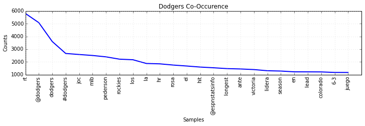

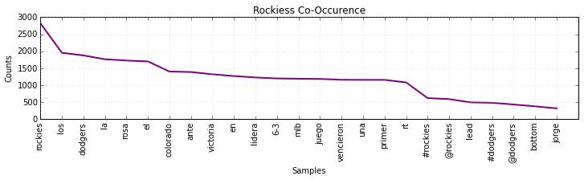

```python
%matplotlib inline
import matplotlib
import numpy as np
import matplotlib.pyplot as plt

plt.figure(figsize=(12,5))
plt.figure(1)
plt.subplot(211)
plt.title(r'Dodgers Co-Occurence')
plt.xlabel('word')
plt.ylabel('count')
dod_freq_dist.plot(25, color = "blue")

plt.figure(figsize=(12,5))
plt.subplot(212)
plt.title(r'Rockiess Co-Occurence')
plt.xlabel('word')
plt.ylabel('count')
rock_freq_dist.plot(25, color = "purple")
```

Lastly, we will have a look at the source of the tweets. We note that a vast majority of tweets for the Dodgers came in through an iPhone, as opposed to most Rockies tweets coming from twitter itself.

```python
import vincent
vincent.core.initialize_notebook()
area = vincent.Bar(dodgers.source.value_counts().head(10))
area.colors(brew='Spectral')
area.axis_titles(x = "Dodgers Source", y='')
area.display()

vincent.core.initialize_notebook()
area = vincent.Bar(rockies.source.value_counts().head(10))
area.colors(brew='Set2')
area.axis_titles(x = "Rockies Source", y='')
area.display()
```

[output not shown]

I also tracked the geolocation of the tweets coming in, but a vast majority of tweets were not tagged. This could be interesting to put on a map, creating a visualization of each team's fanbase.